# Project Code

Team name

Author

Anirudh Poranki, Ishika Vanwari, Nicole Birova, and Ribhav Sikka

Published

February 27, 2023

Abstract

## 1 Data quality check / cleaning / preparation

Put code with comments. The comments should explain the code such that it can be easily understood. You may put text *(in a markdown cell)* before a large chunk of code to explain the overall purpose of the code, if it is not intuitive. **Put the name of the person / persons who contributed to each code chunk / set of code chunks.** An example is given below.

```python
import pandas as pd
import numpy as np
import seaborn as sns
import matplotlib.pyplot as plt
import time
import itertools
import statsmodels.formula.api as smf
import statsmodels.api as sm
```

```python
data = pd.read_csv("bottle.csv")
```

### 1.1 Data quality check

*By Elton John*

```python
data.describe()
```

|  | Cst_Cnt | Btl_Cnt | Depthm | T_degC | Salnty | O2ml_L | STheta | O2Sat | Oxy_µmol/Kg | BtlNum | ... | R_CHLA | R_PHAEO | R_PRES | R_SAMP | DIC1 | DIC2 | TA1 | TA2 | pH2 | pH1 |
| --- | --- | --- | --- | --- | --- | --- | --- | --- | --- | --- | --- | --- | --- | --- | --- | --- | --- | --- | --- | --- | --- |
| count | 864863.000000 | 864863.000000 | 864863.000000 | 853900.000000 | 817509.000000 | 696201.000000 | 812174.000000 | 661274.000000 | 661268.000000 | 118667.000000 | ... | 225276.000000 | 225275.000000 | 864863.000000 | 122006.000000 | 1999.000000 | 224.000000 | 2084.000000 | 234.000000 | 10.000000 | 84.000000 |
| mean | 17138.790958 | 432432.000000 | 226.831951 | 10.799677 | 33.840350 | 3.392468 | 25.819394 | 57.103779 | 148.808694 | 10.497426 | ... | 0.450225 | 0.198599 | 228.395694 | 162.071521 | 2153.239714 | 2168.148330 | 2256.055845 | 2278.858803 | 7.948570 | 7.910983 |
| std | 10240.949817 | 249664.587267 | 316.050259 | 4.243825 | 0.461843 | 2.073256 | 1.167787 | 37.094137 | 90.187533 | 6.189688 | ... | 1.208566 | 0.376539 | 319.456731 | 85.722796 | 112.995202 | 154.852332 | 34.844435 | 58.496495 | 0.021216 | 0.077666 |
| min | 1.000000 | 1.000000 | 0.000000 | 1.440000 | 28.431000 | -0.010000 | 20.934000 | -0.100000 | -0.434900 | 0.000000 | ... | -0.010000 | -3.890000 | 0.000000 | 0.000000 | 1948.850000 | 1969.440000 | 2181.570000 | 2198.150000 | 7.923100 | 7.618300 |
| 25% | 8269.000000 | 216216.500000 | 46.000000 | 7.680000 | 33.488000 | 1.360000 | 24.965000 | 21.100000 | 60.915470 | 5.000000 | ... | 0.050000 | 0.050000 | 46.000000 | 200.000000 | 2028.330000 | 2008.977500 | 2230.322500 | 2229.062500 | 7.931475 | 7.898675 |
| 50% | 16848.000000 | 432432.000000 | 125.000000 | 10.060000 | 33.863000 | 3.440000 | 25.996000 | 54.400000 | 151.064150 | 10.000000 | ... | 0.160000 | 0.110000 | 126.000000 | 206.000000 | 2170.640000 | 2265.885000 | 2244.325000 | 2247.505000 | 7.946650 | 7.928850 |
| 75% | 26557.000000 | 648647.500000 | 300.000000 | 13.880000 | 34.196900 | 5.500000 | 26.646000 | 97.600000 | 240.379600 | 16.000000 | ... | 0.390000 | 0.230000 | 302.000000 | 214.000000 | 2253.810000 | 2315.525000 | 2278.505000 | 2316.452500 | 7.963300 | 7.955100 |
| max | 34404.000000 | 864863.000000 | 5351.000000 | 31.140000 | 37.034000 | 11.130000 | 250.784000 | 214.100000 | 485.701800 | 25.000000 | ... | 66.110000 | 65.300000 | 5458.000000 | 424.000000 | 2367.800000 | 2364.420000 | 2434.900000 | 2437.000000 | 7.988300 | 8.047700 |

8 rows × 70 columns

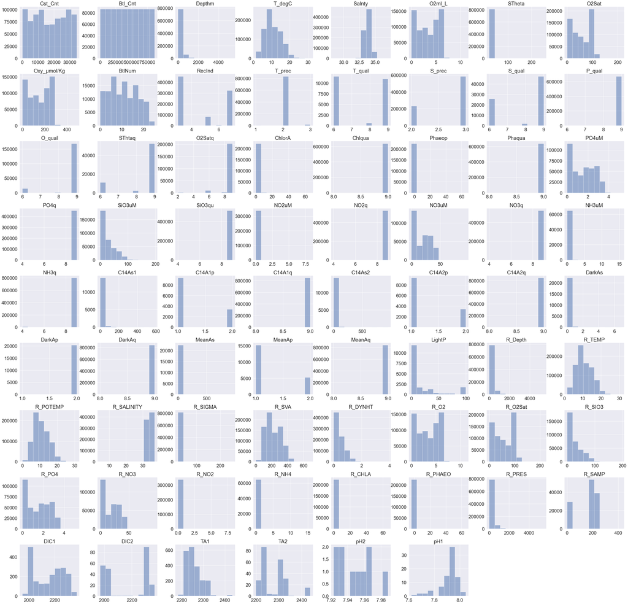

```python
from matplotlib import pyplot
data.hist(alpha=0.5, figsize=(50, 50))
pyplot.show()
```

```python
#...Distribution of continuous variables...#
```

```python
#...Distribution of categorical variables...#
```

```python
#...Association of the response with the predictors...#
```

### 1.2 Data cleaning

*By Ribhav Sikka*

The code below implements the above cleaning.

```python
data.columns
```

```
Index(['Cst_Cnt', 'Btl_Cnt', 'Sta_ID', 'Depth_ID', 'Depthm', 'T_degC',
       'Salnty', 'O2ml_L', 'STheta', 'O2Sat', 'Oxy_µmol/Kg', 'BtlNum',
       'RecInd', 'T_prec', 'T_qual', 'S_prec', 'S_qual', 'P_qual', 'O_qual',
       'SThtaq', 'O2Satq', 'ChlorA', 'Chlqua', 'Phaeop', 'Phaqua', 'PO4uM',
       'PO4q', 'SiO3uM', 'SiO3qu', 'NO2uM', 'NO2q', 'NO3uM', 'NO3q', 'NH3uM',
       'NH3q', 'C14As1', 'C14A1p', 'C14A1q', 'C14As2', 'C14A2p', 'C14A2q',
       'DarkAs', 'DarkAp', 'DarkAq', 'MeanAs', 'MeanAp', 'MeanAq', 'IncTim',
       'LightP', 'R_Depth', 'R_TEMP', 'R_POTEMP', 'R_SALINITY', 'R_SIGMA',
       'R_SVA', 'R_DYNHT', 'R_O2', 'R_O2Sat', 'R_SIO3', 'R_PO4', 'R_NO3',
       'R_NO2', 'R_NH4', 'R_CHLA', 'R_PHAEO', 'R_PRES', 'R_SAMP', 'DIC1',
       'DIC2', 'TA1', 'TA2', 'pH2', 'pH1', 'DIC Quality Comment'],
      dtype='object')
```

Here, we employed 4 steps to find relevant predictors for water temperature. 1) Removed all predictors with missing values greater than 60% of the total values

2. Removed all repeated predictors (all columns with R in front were “rounded” versions of other columns)
3. Removed all predictors with high correlations to other predictors, using data.corr()
4. After additional steps, we realized some of the variables we filled in with missing values (‘C14As1’, ‘C14A1p’, ‘C14A1q’, ‘C14As2’) still had weird correlation/very similar values to each other. We realized that they were probably duplicates, so we removed them as well.

At the end, we were left with data_cleaned = 13 predictors.

```python
#Used this to see how many responses were missing. Removed all greater than 60%
(data.isnull().sum()/len(data)).sort_values()
```

```
Cst_Cnt                0.000000
Btl_Cnt                0.000000
Sta_ID                 0.000000
Depth_ID               0.000000
Depthm                 0.000000
                         ...
TA2                    0.999729
DIC2                   0.999741
pH1                    0.999903
DIC Quality Comment    0.999936
pH2                    0.999988
Length: 74, dtype: float64
```

```python
data_cleaned = data.loc[:,["Depthm","T_degC","Salnty","O2ml_L","STheta","RecInd","T_prec","S_prec","P_qual","Chlqua","Phaqua","NH3q","C14A1q"]]
```

#### 1.2.1 Imputing Missing Values

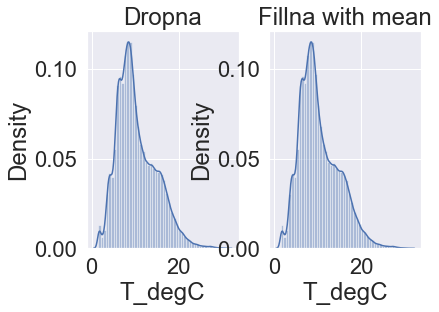

```python
fig, ax=plt.subplots(1,2)
sns.distplot(data_cleaned.T_degC.dropna(), ax=ax[0])
ax[0].set_title("Dropna")
sns.distplot(data_cleaned.T_degC.fillna(data_cleaned.T_degC.mean()), ax=ax[1])
ax[1].set_title("Fillna with mean")
```

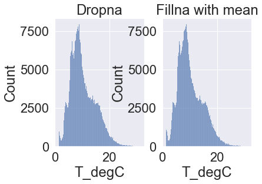

```python
fig, ax=plt.subplots(1,2)
sns.histplot(data_cleaned.T_degC.dropna(), ax=ax[0])
ax[0].set_title("Dropna")
sns.histplot(data_cleaned.T_degC.fillna(data_cleaned.T_degC.mean()), ax=ax[1])
ax[1].set_title("Fillna with mean")
```

```python
#decide to drop missing values for the temperature variable as this is the response/target variable
data_cleaned = data_cleaned[data_cleaned['T_degC'].notna()]
#decide to drop missing values from salinity variable as well due to spike
data_cleaned = data_cleaned[data_cleaned['Salnty'].notna()]
```

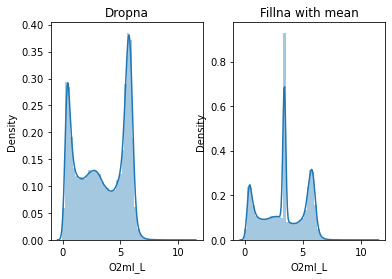

```python
fig, ax=plt.subplots(1,2)
sns.distplot(data_cleaned.O2ml_L.dropna(), ax=ax[0])
ax[0].set_title("Dropna")
sns.distplot(data_cleaned.O2ml_L.fillna(data_cleaned.O2ml_L.mean()), ax=ax[1])
ax[1].set_title("Fillna with mean")
```

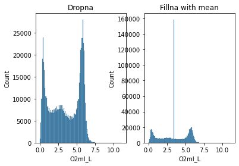

```python
fig, ax=plt.subplots(1,2)
sns.histplot(data_cleaned.O2ml_L.dropna(), ax=ax[0])
ax[0].set_title("Dropna")
sns.histplot(data_cleaned.O2ml_L.fillna(data_cleaned.O2ml_L.mean()), ax=ax[1])
ax[1].set_title("Fillna with mean")
```

```python
#decide to drop to avoid spike for O2ml_L variable
data_cleaned = data_cleaned[data_cleaned['O2ml_L'].notna()]
```

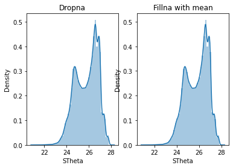

```python
fig, ax=plt.subplots(1,2)
sns.distplot(data_cleaned.STheta.dropna(), ax=ax[0])
ax[0].set_title("Dropna")
sns.distplot(data_cleaned.STheta.fillna(data_cleaned.STheta.mean()), ax=ax[1])
ax[1].set_title("Fillna with mean")
```

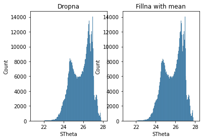

```python
fig, ax=plt.subplots(1,2)
sns.histplot(data_cleaned.STheta.dropna(), ax=ax[0])
ax[0].set_title("Dropna")
sns.histplot(data_cleaned.STheta.fillna(data_cleaned.STheta.mean()), ax=ax[1])
ax[1].set_title("Fillna with mean")
```

```python
#decide to fill in with mean as there is no spike to avoid
data_cleaned['STheta'] = data_cleaned['STheta'].fillna(data_cleaned['STheta'].mean())
```

```python
#Decided to drop missing values as they all had high spikes
data_cleaned = data_cleaned[data_cleaned['P_qual'].notna()]
data_cleaned = data_cleaned[data_cleaned['Chlqua'].notna()]
data_cleaned = data_cleaned[data_cleaned['Phaqua'].notna()]
data_cleaned = data_cleaned[data_cleaned['NH3q'].notna()]
data_cleaned = data_cleaned[data_cleaned['C14A1q'].notna()]
```

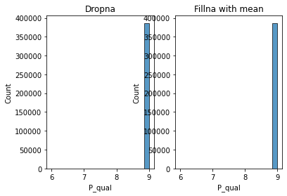

```python
fig, ax=plt.subplots(1,2)
sns.histplot(data_cleaned.P_qual.dropna(), ax=ax[0])
ax[0].set_title("Dropna")
sns.histplot(data_cleaned.P_qual.fillna(data_cleaned.P_qual.mean()), ax=ax[1])
ax[1].set_title("Fillna with mean")
```

## 2 Exploratory data analysis

Put code with comments. The comments should explain the code such that it can be easily understood. You may put text *(in a markdown cell)* before a large chunk of code to explain the overall purpose of the code, if it is not intuitive. **Put the name of the person / persons who contributed to each code chunk / set of code chunks.**

```python
correlation = data_cleaned.corr()
correlation
```

|  | Depthm | T_degC | Salnty | O2ml_L | STheta | RecInd | T_prec | S_prec | P_qual | Chlqua | Phaqua | NH3q | C14A1q |
| --- | --- | --- | --- | --- | --- | --- | --- | --- | --- | --- | --- | --- | --- |
| Depthm | 1.000000 | -0.660287 | 0.511076 | -0.538436 | 0.658770 | 0.081390 | 0.040641 | 0.108113 | 0.001086 | NaN | NaN | NaN | NaN |
| T_degC | -0.660287 | 1.000000 | -0.375203 | 0.758085 | -0.959316 | -0.116642 | -0.027041 | -0.157821 | -0.000917 | NaN | NaN | NaN | NaN |
| Salnty | 0.511076 | -0.375203 | 1.000000 | -0.768031 | 0.600669 | 0.061246 | -0.000591 | 0.098107 | 0.003341 | NaN | NaN | NaN | NaN |
| O2ml_L | -0.538436 | 0.758085 | -0.768031 | 1.000000 | -0.870741 | -0.102903 | -0.001954 | -0.123962 | -0.002352 | NaN | NaN | NaN | NaN |
| STheta | 0.658770 | -0.959316 | 0.600669 | -0.870741 | 1.000000 | 0.113826 | 0.022240 | 0.163444 | 0.001755 | NaN | NaN | NaN | NaN |
| RecInd | 0.081390 | -0.116642 | 0.061246 | -0.102903 | 0.113826 | 1.000000 | 0.083007 | 0.678485 | 0.001585 | NaN | NaN | NaN | NaN |
| T_prec | 0.040641 | -0.027041 | -0.000591 | -0.001954 | 0.022240 | 0.083007 | 1.000000 | 0.067971 | 0.000058 | NaN | NaN | NaN | NaN |
| S_prec | 0.108113 | -0.157821 | 0.098107 | -0.123962 | 0.163444 | 0.678485 | 0.067971 | 1.000000 | -0.001151 | NaN | NaN | NaN | NaN |
| P_qual | 0.001086 | -0.000917 | 0.003341 | -0.002352 | 0.001755 | 0.001585 | 0.000058 | -0.001151 | 1.000000 | NaN | NaN | NaN | NaN |
| Chlqua | NaN | NaN | NaN | NaN | NaN | NaN | NaN | NaN | NaN | NaN | NaN | NaN | NaN |
| Phaqua | NaN | NaN | NaN | NaN | NaN | NaN | NaN | NaN | NaN | NaN | NaN | NaN | NaN |
| NH3q | NaN | NaN | NaN | NaN | NaN | NaN | NaN | NaN | NaN | NaN | NaN | NaN | NaN |
| C14A1q | NaN | NaN | NaN | NaN | NaN | NaN | NaN | NaN | NaN | NaN | NaN | NaN | NaN |

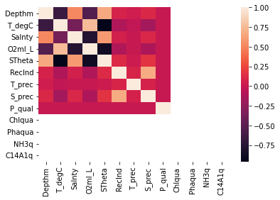

```python
sns.heatmap(correlation)
```

```python
data_cleaned.drop(['Chlqua','Phaqua','NH3q','C14A1q'],axis = 1, inplace = True)
```

Seems like T_degC is very closely related to Depthm, STheta and O2ml_L. However, STheta and Depthm also have really high correlations, along with Slnty & O2ml_L. It seems like the main predictors have pretty close correlations with each other - perhaps only one of these predictors will have most of the explanatory power.

In our presentation model, we noticed that STheta had most of the predicting power. We expect that to occur again, so we decided to make multiple models. One with Stheta, one without Stheta, and one without any of the variables that correlate heavily with Stheta.

Additionally, it seems like ‘Chlqua’,‘Phaqua’,‘NH3q’,‘C14A1q’ are similar values once you drop the missing values from the initial dataset. Thus, we decided to drop these columns as well. The lack of correlation is also troubling.

### 2.1 Data preparation

*By Ishika Vanwari*

The following data preparation steps helped us to prepare our data for implementing various modeling / validation techniques:

1. Since we needed to predict water temperature, we decided to use an 80/20 split to conserve our training data but have enough for our test data.
2. Later on, we also standarized the data for Lasso and Ridge. However, we put the code later on near the actual development.

```python
#Creaing training and testing split
split = (np.random.rand(len(data_cleaned)) <= 0.8)
training = data_cleaned[split]
testing = data_cleaned[~split]

print(f"No. of training examples: {training.shape[0]}")
print(f"No. of testing examples: {testing.shape[0]}")
```

```
No. of training examples: 308807
No. of testing examples: 77565
```

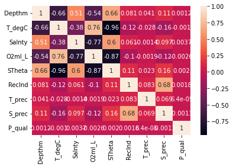

```python
sns.heatmap(training.corr(), annot= True)
```

```python
from statsmodels.stats.outliers_influence import variance_inflation_factor

for j in range(len(training.columns)):
    vif_data = pd.DataFrame()
    vif_data["feature"] = training.columns
    vif_data["VIF"] = [variance_inflation_factor(training.values, i) for i in range(len(training.columns))]
    vif_data = vif_data.sort_values(by= 'VIF', ascending= False)
    if(vif_data.VIF.max() < 30):
        df_bottle_train_scaled = training.drop(vif_data.feature[1], axis= 1)
        vif_data = vif_data.drop(['feature', 'VIF'], axis= 1)
        vif_data.reset_index(drop= True, inplace= True)
    else:
        print(vif_data)
        break
```

```
  feature            VIF
2  Salnty  106304.859486
4  STheta   89804.426539
8  P_qual   26760.320895
1  T_degC     764.066613
6  T_prec     449.802757
7  S_prec      61.888486
3  O2ml_L      23.837490
5  RecInd      13.466171
0  Depthm       6.318763
```

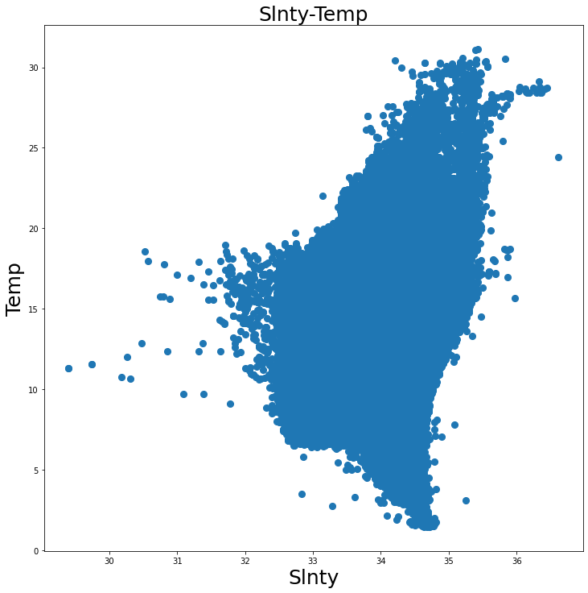

```python
plt.figure(figsize=(12, 12))
plt.scatter(training["Salnty"], training["T_degC"],s=65)
plt.xlabel('Slnty',fontsize=25)
plt.ylabel('Temp',fontsize=25)
plt.title('Slnty-Temp',fontsize=25)
plt.show()
```

```python
new = training[:][:750]
len(new)
```

```
750
```

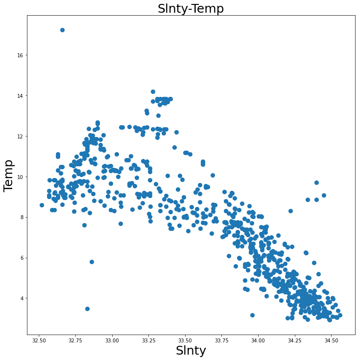

```python
plt.figure(figsize=(12, 12))
plt.scatter(new["Salnty"], new["T_degC"],s=65)
plt.xlabel('Slnty',fontsize=25)
plt.ylabel('Temp',fontsize=25)
plt.title('Slnty-Temp',fontsize=25)
plt.show()
```

```python
from sklearn.linear_model import LinearRegression
Slt = new.iloc[:, 0:1].values
Tmp = new.iloc[:, -1].values
lin_reg=LinearRegression()
lin_reg.fit(Slt,Tmp)
```

```
LinearRegression()
```

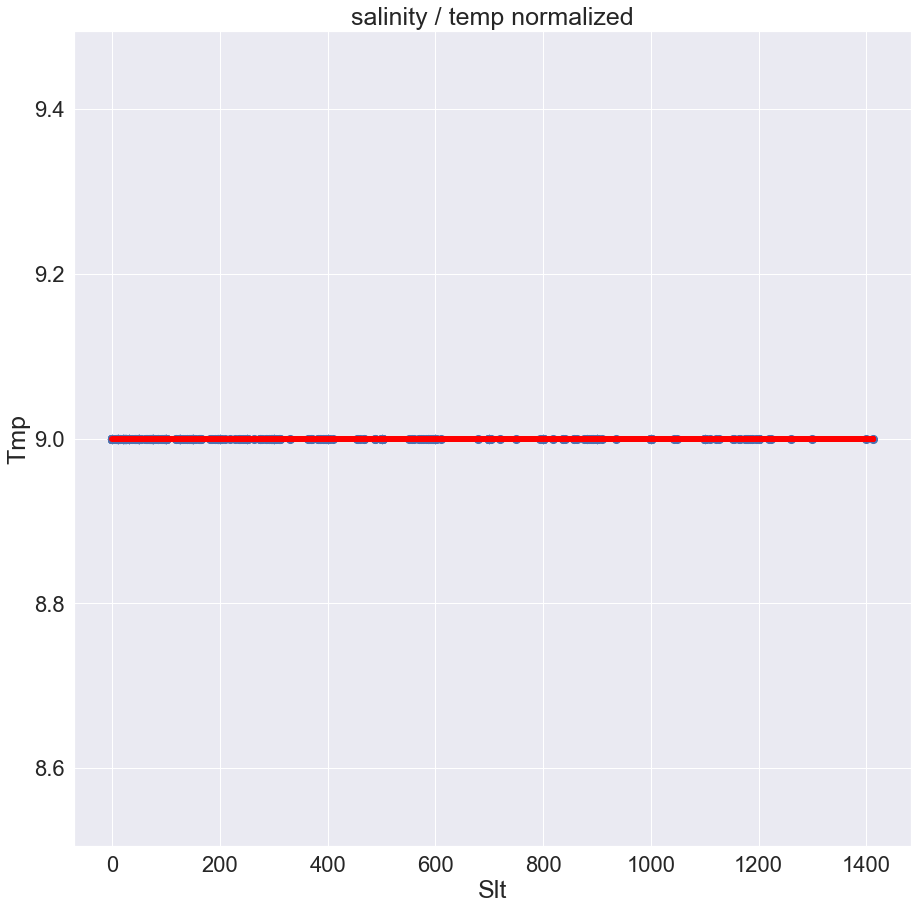

```python
sns.set(font_scale=2)
plt.figure(figsize=(15, 15))
plt.scatter(Slt,Tmp,s=65)
plt.plot(Slt,lin_reg.predict(Slt), color='red', linewidth='6')
plt.xlabel('Slt',fontsize=25)
plt.ylabel('Tmp',fontsize=25)
plt.title('salinity / temp normalized',fontsize=25)
plt.show()
```

```python
from sklearn.metrics import mean_squared_error,r2_score
Tmp_head_lin=lin_reg.predict(Slt)
print("Linear Regression R_Square Score: " ,r2_score(Tmp,Tmp_head_lin))
#["Linear Regression R_Square Score:"]=r2_score(Tmp,Tmp_head_lin)
```

```
Linear Regression R_Square Score:  1.0
```

## 3 Developing the model

#### 3.0.1 Simple Linear Regression

```python
#Ribhav Sikka
import statsmodels.formula.api as smf
import seaborn as sns
import matplotlib.pyplot as plt
ols_object = smf.ols(formula = 'T_degC~STheta', data = training)
```

```python
model = ols_object.fit()
model.summary()
```

OLS Regression Results

| Dep. Variable: | T_degC | R-squared: | 0.920 |
| --- | --- | --- | --- |
| Model: | OLS | Adj. R-squared: | 0.920 |
| Method: | Least Squares | F-statistic: | 3.569e+06 |
| Date: | Tue, 14 Mar 2023 | Prob (F-statistic): | 0.00 |
| Time: | 22:56:51 | Log-Likelihood: | -5.1140e+05 |
| No. Observations: | 308807 | AIC: | 1.023e+06 |
| Df Residuals: | 308805 | BIC: | 1.023e+06 |
| Df Model: | 1 |  |  |
| Covariance Type: | nonrobust |  |  |

|  | coef | std err | t | P>\|t\| | [0.025 | 0.975] |
| --- | --- | --- | --- | --- | --- | --- |
| Intercept | 120.5298 | 0.058 | 2064.078 | 0.000 | 120.415 | 120.644 |
| STheta | -4.2390 | 0.002 | -1889.296 | 0.000 | -4.243 | -4.235 |

| Omnibus: | 55626.723 | Durbin-Watson: | 0.099 |
| --- | --- | --- | --- |
| Prob(Omnibus): | 0.000 | Jarque-Bera (JB): | 213963.746 |
| Skew: | 0.867 | Prob(JB): | 0.00 |
| Kurtosis: | 6.691 | Cond. No. | 667. |

Notes:  
[1] Standard Errors assume that the covariance matrix of the errors is correctly specified.

```python
#Ribhav Sikka
import statsmodels.formula.api as smf
import seaborn as sns
import matplotlib.pyplot as plt
ols_object = smf.ols(formula = 'T_degC~O2ml_L+STheta', data = training)
```

```python
model = ols_object.fit()
model.summary()
```

OLS Regression Results

| Dep. Variable: | T_degC | R-squared: | 0.945 |
| --- | --- | --- | --- |
| Model: | OLS | Adj. R-squared: | 0.945 |
| Method: | Least Squares | F-statistic: | 2.659e+06 |
| Date: | Tue, 14 Mar 2023 | Prob (F-statistic): | 0.00 |
| Time: | 22:56:52 | Log-Likelihood: | -4.5394e+05 |
| No. Observations: | 308807 | AIC: | 9.079e+05 |
| Df Residuals: | 308804 | BIC: | 9.079e+05 |
| Df Model: | 2 |  |  |
| Covariance Type: | nonrobust |  |  |

|  | coef | std err | t | P>\|t\| | [0.025 | 0.975] |
| --- | --- | --- | --- | --- | --- | --- |
| Intercept | 154.6342 | 0.103 | 1494.550 | 0.000 | 154.431 | 154.837 |
| O2ml_L | -0.6969 | 0.002 | -373.115 | 0.000 | -0.701 | -0.693 |
| STheta | -5.4721 | 0.004 | -1442.420 | 0.000 | -5.480 | -5.465 |

| Omnibus: | 74827.187 | Durbin-Watson: | 0.199 |
| --- | --- | --- | --- |
| Prob(Omnibus): | 0.000 | Jarque-Bera (JB): | 941112.581 |
| Skew: | 0.814 | Prob(JB): | 0.00 |
| Kurtosis: | 11.396 | Cond. No. | 1.43e+03 |

Notes:  
[1] Standard Errors assume that the covariance matrix of the errors is correctly specified.  
[2] The condition number is large, 1.43e+03. This might indicate that there are  
strong multicollinearity or other numerical problems.

```python
#Ribhav Sikka
import statsmodels.formula.api as smf
import seaborn as sns
import matplotlib.pyplot as plt
ols_object = smf.ols(formula = 'T_degC~O2ml_L+Salnty+STheta', data = training)
```

```python
model = ols_object.fit()
model.summary()
```

OLS Regression Results

| Dep. Variable: | T_degC | R-squared: | 0.984 |
| --- | --- | --- | --- |
| Model: | OLS | Adj. R-squared: | 0.984 |
| Method: | Least Squares | F-statistic: | 6.151e+06 |
| Date: | Tue, 14 Mar 2023 | Prob (F-statistic): | 0.00 |
| Time: | 22:58:12 | Log-Likelihood: | -2.6800e+05 |
| No. Observations: | 308807 | AIC: | 5.360e+05 |
| Df Residuals: | 308803 | BIC: | 5.361e+05 |
| Df Model: | 3 |  |  |
| Covariance Type: | nonrobust |  |  |

|  | coef | std err | t | P>\|t\| | [0.025 | 0.975] |
| --- | --- | --- | --- | --- | --- | --- |
| Intercept | 37.0454 | 0.150 | 247.560 | 0.000 | 36.752 | 37.339 |
| O2ml_L | -0.0037 | 0.001 | -2.808 | 0.005 | -0.006 | -0.001 |
| Salnty | 3.1032 | 0.004 | 849.019 | 0.000 | 3.096 | 3.110 |
| STheta | -5.0824 | 0.002 | -2388.678 | 0.000 | -5.087 | -5.078 |

| Omnibus: | 88079.265 | Durbin-Watson: | 0.220 |
| --- | --- | --- | --- |
| Prob(Omnibus): | 0.000 | Jarque-Bera (JB): | 499790.626 |
| Skew: | -1.257 | Prob(JB): | 0.00 |
| Kurtosis: | 8.703 | Cond. No. | 6.19e+03 |

Notes:  
[1] Standard Errors assume that the covariance matrix of the errors is correctly specified.  
[2] The condition number is large, 6.19e+03. This might indicate that there are  
strong multicollinearity or other numerical problems.

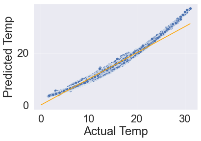

```python
#Nicole Birova
pred = model.predict(testing)
sns.scatterplot(x = testing.T_degC, y = pred)
#In case of a perfect prediction, all the points must lie on the line x = y.
sns.lineplot(x = [0,testing.T_degC.max()], y = [0,testing.T_degC.max()],color='orange') #Plotting the line x = y.
plt.xlabel('Actual Temp')
plt.ylabel('Predicted Temp')
```

```python
###RMSE
np.sqrt(((testing.T_degC - pred)**2).mean())
```

```
0.5815642774307529
```

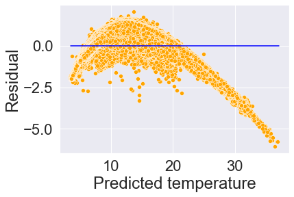

```python
sns.scatterplot(x = model.fittedvalues, y=model.resid,color = 'orange')
sns.lineplot(x = [pred.min(),pred.max()],y = [0,0],color = 'blue')
plt.xlabel('Predicted temperature')
plt.ylabel('Residual')
```

```python
#Nicole Birova
import statsmodels.formula.api as sm
import time
import itertools

model = sm.ols('np.log(T_degC)~O2ml_L+Salnty+STheta', data = training).fit()
model.summary()
```

OLS Regression Results

| Dep. Variable: | np.log(T_degC) | R-squared: | 0.856 |
| --- | --- | --- | --- |
| Model: | OLS | Adj. R-squared: | 0.856 |
| Method: | Least Squares | F-statistic: | 6.134e+05 |
| Date: | Tue, 14 Mar 2023 | Prob (F-statistic): | 0.00 |
| Time: | 22:58:40 | Log-Likelihood: | 98394. |
| No. Observations: | 308807 | AIC: | -1.968e+05 |
| Df Residuals: | 308803 | BIC: | -1.967e+05 |
| Df Model: | 3 |  |  |
| Covariance Type: | nonrobust |  |  |

|  | coef | std err | t | P>\|t\| | [0.025 | 0.975] |
| --- | --- | --- | --- | --- | --- | --- |
| Intercept | 12.7486 | 0.046 | 279.059 | 0.000 | 12.659 | 12.838 |
| O2ml_L | -0.0356 | 0.000 | -89.033 | 0.000 | -0.036 | -0.035 |
| Salnty | 0.0782 | 0.001 | 70.108 | 0.000 | 0.076 | 0.080 |
| STheta | -0.5026 | 0.001 | -773.785 | 0.000 | -0.504 | -0.501 |

| Omnibus: | 120920.687 | Durbin-Watson: | 0.194 |
| --- | --- | --- | --- |
| Prob(Omnibus): | 0.000 | Jarque-Bera (JB): | 664352.810 |
| Skew: | -1.816 | Prob(JB): | 0.00 |
| Kurtosis: | 9.201 | Cond. No. | 6.19e+03 |

Notes:  
[1] Standard Errors assume that the covariance matrix of the errors is correctly specified.  
[2] The condition number is large, 6.19e+03. This might indicate that there are  
strong multicollinearity or other numerical problems.

```
Processed 4 models on 1 predictors in 0.21367096900939941 seconds.
Processed 6 models on 2 predictors in 0.46698713302612305 seconds.
Processed 4 models on 3 predictors in 0.34276914596557617 seconds.
Processed 1 models on 4 predictors in 0.10579109191894531 seconds.
Total elapsed time: 1.1673200130462646 seconds.
```

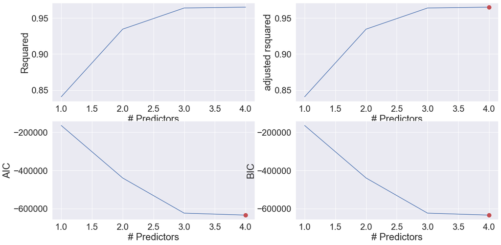

```python
#Creating a set of predictors from which we need to find the best subset of predictors
X = training[['Depthm','Salnty', 'O2ml_L','STheta']]
def processSubset(predictor_subset):
    # Fit model on feature_set and calculate R-squared
    model = sm.ols('np.log(T_degC)~' + '+'.join(predictor_subset),data = training).fit()
    Rsquared = model.rsquared
    return {"model":model, "Rsquared":Rsquared}
def getBest_model(k):
    tic = time.time()
    results = []
    for combo in itertools.combinations(X.columns, k):
        results.append(processSubset((list(combo))))

    models = pd.DataFrame(results)

    best_model = models.loc[models['Rsquared'].argmax()]

    toc = time.time()
    print("Processed", models.shape[0], "models on", k, "predictors in", (toc-tic), "seconds.")
    return best_model
models_best = pd.DataFrame(columns=["Rsquared", "model"])

tic = time.time()
for i in range(1,1+X.shape[1]):
    models_best.loc[i] = getBest_model(i)

toc = time.time()
print("Total elapsed time:", (toc-tic), "seconds.")

def best_sub_plots():
    plt.figure(figsize=(20,10))
    plt.rcParams.update({'font.size': 18, 'lines.markersize': 10})

    # Set up a 2x2 grid so we can look at 4 plots at once
    plt.subplot(2, 2, 1)

    # We will now plot a red dot to indicate the model with the largest adjusted R^2 statistic.
    # The argmax() function can be used to identify the location of the maximum point of a vector
    plt.plot(models_best["Rsquared"])
    plt.xlabel('# Predictors')
    plt.ylabel('Rsquared')

    # We will now plot a red dot to indicate the model with the largest adjusted R^2 statistic.
    # The argmax() function can be used to identify the location of the maximum point of a vector

    rsquared_adj = models_best.apply(lambda row: row[1].rsquared_adj, axis=1)

    plt.subplot(2, 2, 2)
    plt.plot(rsquared_adj)
    plt.plot(1+rsquared_adj.argmax(), rsquared_adj.max(), "or")
    plt.xlabel('# Predictors')
    plt.ylabel('adjusted rsquared')

    # We'll do the same for AIC and BIC, this time looking for the models with the SMALLEST statistic
    aic = models_best.apply(lambda row: row[1].aic, axis=1)

    plt.subplot(2, 2, 3)
    plt.plot(aic)
    plt.plot(1+aic.argmin(), aic.min(), "or")
    plt.xlabel('# Predictors')
    plt.ylabel('AIC')

    bic = models_best.apply(lambda row: row[1].bic, axis=1)

    plt.subplot(2, 2, 4)
    plt.plot(bic)
    plt.plot(1+bic.argmin(), bic.min(), "or")
    plt.xlabel('# Predictors')
    plt.ylabel('BIC')
best_sub_plots()
```

```python
best = models_best.loc[4,'model']
models_best.loc[4,'model'].summary()
```

OLS Regression Results

| Dep. Variable: | np.log(T_degC) | R-squared: | 0.965 |
| --- | --- | --- | --- |
| Model: | OLS | Adj. R-squared: | 0.965 |
| Method: | Least Squares | F-statistic: | 2.137e+06 |
| Date: | Tue, 14 Mar 2023 | Prob (F-statistic): | 0.00 |
| Time: | 22:59:57 | Log-Likelihood: | 3.1706e+05 |
| No. Observations: | 308807 | AIC: | -6.341e+05 |
| Df Residuals: | 308802 | BIC: | -6.341e+05 |
| Df Model: | 4 |  |  |
| Covariance Type: | nonrobust |  |  |

|  | coef | std err | t | P>\|t\| | [0.025 | 0.975] |
| --- | --- | --- | --- | --- | --- | --- |
| Intercept | 1.5429 | 0.025 | 61.149 | 0.000 | 1.493 | 1.592 |
| Depthm | -0.0006 | 5.94e-07 | -981.776 | 0.000 | -0.001 | -0.001 |
| Salnty | 0.2622 | 0.001 | 451.539 | 0.000 | 0.261 | 0.263 |
| O2ml_L | 0.0209 | 0.000 | 102.030 | 0.000 | 0.021 | 0.021 |
| STheta | -0.3121 | 0.000 | -834.141 | 0.000 | -0.313 | -0.311 |

| Omnibus: | 96732.108 | Durbin-Watson: | 0.238 |
| --- | --- | --- | --- |
| Prob(Omnibus): | 0.000 | Jarque-Bera (JB): | 3801071.482 |
| Skew: | 0.816 | Prob(JB): | 0.00 |
| Kurtosis: | 20.110 | Cond. No. | 7.55e+04 |

Notes:  
[1] Standard Errors assume that the covariance matrix of the errors is correctly specified.  
[2] The condition number is large, 7.55e+04. This might indicate that there are  
strong multicollinearity or other numerical problems.

```python
pred = np.exp(best.predict(testing))
np.sqrt(((pred - testing.T_degC)**2).mean())
```

```
1.2919002605408938
```

```python
#Nicole Birova
model = sm.ols('np.log(T_degC)~' + '+'.join(X.columns),data = training).fit()
pred = np.exp(model.predict(testing))
np.sqrt(((pred - testing.T_degC)**2).mean())
##same because the optimal model uses all the columns
```

```
1.2919002605408938
```

```python
##Nicole Birova
X = training[['Depthm','Salnty', 'O2ml_L','STheta']]
#Since 'X' will change when we include interactions, we need a backup
X_backup = training[['Depthm','Salnty', 'O2ml_L','STheta']]
for combo in itertools.combinations(X_backup.columns, 2):
    training['_'.join(combo)] = training[combo[0]]*training[combo[1]]
    testing['_'.join(combo)] = testing[combo[0]]*testing[combo[1]]
    X.loc[:,'_'.join(combo)] = training.loc[:,'_'.join(combo)]

models_best = pd.DataFrame(columns=["Rsquared", "model"])
#attempted to do best subsets with two-factor interactions, however the kernel keeps dying
```

```
Processed  10 models on 1 predictors in 0.7364091873168945 seconds.
Processed  9 models on 2 predictors in 0.8026680946350098 seconds.
Processed  8 models on 3 predictors in 0.8656272888183594 seconds.
Processed  7 models on 4 predictors in 0.8517279624938965 seconds.
Processed  6 models on 5 predictors in 0.8621628284454346 seconds.
Processed  5 models on 6 predictors in 0.7506086826324463 seconds.
Processed  4 models on 7 predictors in 0.8338608741760254 seconds.
Processed  3 models on 8 predictors in 0.6452069282531738 seconds.
Processed  2 models on 9 predictors in 0.4496181011199951 seconds.
Processed  1 models on 10 predictors in 0.27166295051574707 seconds.
Total elapsed time: 7.34417986869812 seconds.
```

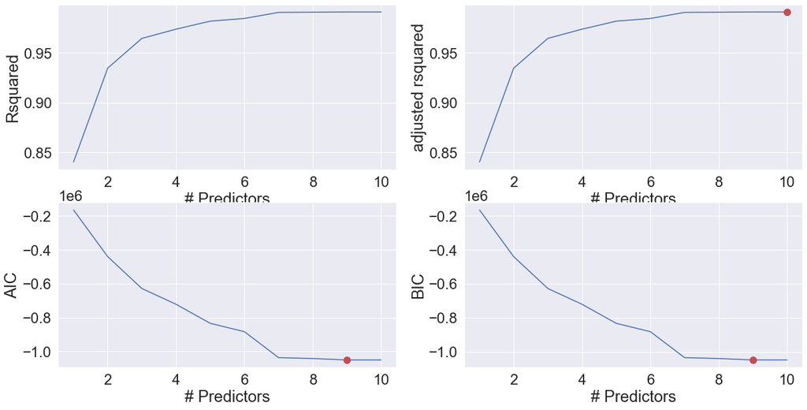

```python
def forward(predictors):
    remaining_predictors = [p for p in X.columns if p not in predictors]
    tic = time.time()
    results = []

    for p in remaining_predictors:
        results.append(processSubset(predictors+[p]))

    models = pd.DataFrame(results)
    best_model = models.loc[models['Rsquared'].argmax()]

    toc = time.time()
    print("Processed ", models.shape[0], "models on", len(predictors)+1, "predictors in", (toc-tic), "seconds.")
    return best_model
def forward_selection():
    models_best = pd.DataFrame(columns=["Rsquared", "model"])

    tic = time.time()
    predictors = []

    for i in range(1,len(X.columns)+1):
        models_best.loc[i] = forward(predictors)
        predictors = list(models_best.loc[i]["model"].params.index[1:])

    toc = time.time()
    print("Total elapsed time:", (toc-tic), "seconds.")
    return models_best

models_best = forward_selection()
best_sub_plots()
```

```python
best_fwd_reg_model = models_best['model'][10]
best_fwd_reg_model.summary()
```

OLS Regression Results

| Dep. Variable: | np.log(T_degC) | R-squared: | 0.991 |
| --- | --- | --- | --- |
| Model: | OLS | Adj. R-squared: | 0.991 |
| Method: | Least Squares | F-statistic: | 3.370e+06 |
| Date: | Tue, 14 Mar 2023 | Prob (F-statistic): | 0.00 |
| Time: | 23:02:11 | Log-Likelihood: | 5.2478e+05 |
| No. Observations: | 308807 | AIC: | -1.050e+06 |
| Df Residuals: | 308796 | BIC: | -1.049e+06 |
| Df Model: | 10 |  |  |
| Covariance Type: | nonrobust |  |  |

|  | coef | std err | t | P>\|t\| | [0.025 | 0.975] |
| --- | --- | --- | --- | --- | --- | --- |
| Intercept | 58.5945 | 0.305 | 192.134 | 0.000 | 57.997 | 59.192 |
| STheta | -2.4453 | 0.012 | -202.937 | 0.000 | -2.469 | -2.422 |
| Depthm_STheta | -0.0007 | 1.73e-06 | -432.294 | 0.000 | -0.001 | -0.001 |
| Salnty_STheta | 0.0617 | 0.000 | 177.689 | 0.000 | 0.061 | 0.062 |
| Depthm_O2ml_L | 7.27e-05 | 3.25e-07 | 223.675 | 0.000 | 7.21e-05 | 7.33e-05 |
| Salnty | -1.3889 | 0.009 | -157.784 | 0.000 | -1.406 | -1.372 |
| Depthm_Salnty | 0.0014 | 3.23e-06 | 421.529 | 0.000 | 0.001 | 0.001 |
| Depthm | -0.0272 | 8.19e-05 | -332.195 | 0.000 | -0.027 | -0.027 |
| O2ml_L_STheta | 0.0123 | 0.000 | 93.226 | 0.000 | 0.012 | 0.013 |
| O2ml_L | -0.3027 | 0.006 | -46.867 | 0.000 | -0.315 | -0.290 |
| Salnty_O2ml_L | -0.0002 | 0.000 | -1.181 | 0.238 | -0.001 | 0.000 |

| Omnibus: | 114998.499 | Durbin-Watson: | 0.322 |
| --- | --- | --- | --- |
| Prob(Omnibus): | 0.000 | Jarque-Bera (JB): | 46544586.360 |
| Skew: | 0.407 | Prob(JB): | 0.00 |
| Kurtosis: | 63.139 | Cond. No. | 7.87e+07 |

Notes:  
[1] Standard Errors assume that the covariance matrix of the errors is correctly specified.  
[2] The condition number is large, 7.87e+07. This might indicate that there are  
strong multicollinearity or other numerical problems.

```python
pred_price = np.exp(best_fwd_reg_model.predict(testing))
np.sqrt(((pred_price - testing.T_degC)**2).mean())
```

```
0.6043146211071146
```

```python
#Nicole Birova
import statsmodels.formula.api as smf
import seaborn as sns
import matplotlib.pyplot as plt
ols_object = smf.ols(formula = 'T_degC~STheta', data = training)
```

```python
model = ols_object.fit()
model.summary()
```

OLS Regression Results

| Dep. Variable: | T_degC | R-squared: | 0.920 |
| --- | --- | --- | --- |
| Model: | OLS | Adj. R-squared: | 0.920 |
| Method: | Least Squares | F-statistic: | 3.569e+06 |
| Date: | Tue, 14 Mar 2023 | Prob (F-statistic): | 0.00 |
| Time: | 23:02:53 | Log-Likelihood: | -5.1140e+05 |
| No. Observations: | 308807 | AIC: | 1.023e+06 |
| Df Residuals: | 308805 | BIC: | 1.023e+06 |
| Df Model: | 1 |  |  |
| Covariance Type: | nonrobust |  |  |

|  | coef | std err | t | P>\|t\| | [0.025 | 0.975] |
| --- | --- | --- | --- | --- | --- | --- |
| Intercept | 120.5298 | 0.058 | 2064.078 | 0.000 | 120.415 | 120.644 |
| STheta | -4.2390 | 0.002 | -1889.296 | 0.000 | -4.243 | -4.235 |

| Omnibus: | 55626.723 | Durbin-Watson: | 0.099 |
| --- | --- | --- | --- |
| Prob(Omnibus): | 0.000 | Jarque-Bera (JB): | 213963.746 |
| Skew: | 0.867 | Prob(JB): | 0.00 |
| Kurtosis: | 6.691 | Cond. No. | 667. |

Notes:  
[1] Standard Errors assume that the covariance matrix of the errors is correctly specified.

#### 3.0.2 Model (w STheta)

```python
#Anirudh Poranki
X = training[['Salnty','O2ml_L', 'STheta','RecInd','T_prec','S_prec','P_qual']]
X_backup = training[['Salnty','O2ml_L', 'STheta','RecInd','T_prec','S_prec','P_qual']]
```

```python
for combo in itertools.combinations(X.columns, 2):
    training['_'.join(combo)] = training[combo[0]]*training[combo[1]]
    testing['_'.join(combo)] = testing[combo[0]]*testing[combo[1]]
    X.loc[:,'_'.join(combo)] = training.loc[:,'_'.join(combo)]
```

```python
#Function to develop a model based on all predictors in predictor_subset
def processSubset(predictor_subset):
    # Fit model on feature_set and calculate R-squared
    model = smf.ols('T_degC~' + '+'.join(predictor_subset),data = training).fit()
    Rsquared = model.rsquared
    return {"model":model, "Rsquared":Rsquared}
```

```python
def forward(predictors):

    # Pull out predictors we still need to process
    remaining_predictors = [p for p in X.columns if p not in predictors]

    tic = time.time()

    results = []

    for p in remaining_predictors:
        results.append(processSubset(predictors+[p]))

    # Wrap everything up in a nice dataframe
    models = pd.DataFrame(results)

    # Choose the model with the highest RSS
    best_model = models.loc[models['Rsquared'].argmax()]

    toc = time.time()
    print("Processed ", models.shape[0], "models on", len(predictors)+1, "predictors in", (toc-tic), "seconds.")

    # Return the best model, along with some other useful information about the model
    return best_model
```

```python
def forward_selection():
    models_best = pd.DataFrame(columns=["Rsquared", "model"])

    tic = time.time()
    predictors = []

    for i in range(1,len(X.columns)+1):
        models_best.loc[i] = forward(predictors)
        predictors = list(models_best.loc[i]["model"].params.index[1:])

    toc = time.time()
    print("Total elapsed time:", (toc-tic), "seconds.")
    return models_best
```

#### 3.0.3 Forward Selection

```python
models_best = forward_selection()
```

```
Processed  28 models on 1 predictors in 1.6516270637512207 seconds.
Processed  27 models on 2 predictors in 1.7899739742279053 seconds.
Processed  26 models on 3 predictors in 2.160818099975586 seconds.
Processed  25 models on 4 predictors in 2.541416883468628 seconds.
Processed  24 models on 5 predictors in 2.926903009414673 seconds.
Processed  23 models on 6 predictors in 3.498339891433716 seconds.
Processed  22 models on 7 predictors in 4.072696208953857 seconds.
Processed  21 models on 8 predictors in 4.162523984909058 seconds.
Processed  20 models on 9 predictors in 4.247164011001587 seconds.
Processed  19 models on 10 predictors in 5.831084728240967 seconds.
Processed  18 models on 11 predictors in 5.103785276412964 seconds.
Processed  17 models on 12 predictors in 5.47020697593689 seconds.
Processed  16 models on 13 predictors in 5.346061944961548 seconds.
Processed  15 models on 14 predictors in 5.082754135131836 seconds.
Processed  14 models on 15 predictors in 5.311592102050781 seconds.
Processed  13 models on 16 predictors in 5.419804096221924 seconds.
Processed  12 models on 17 predictors in 5.118685007095337 seconds.
Processed  11 models on 18 predictors in 5.267773866653442 seconds.
Processed  10 models on 19 predictors in 4.694533824920654 seconds.
Processed  9 models on 20 predictors in 4.873488903045654 seconds.
Processed  8 models on 21 predictors in 4.330276966094971 seconds.
Processed  7 models on 22 predictors in 3.910449981689453 seconds.
Processed  6 models on 23 predictors in 3.487940788269043 seconds.
Processed  5 models on 24 predictors in 3.0585672855377197 seconds.
Processed  4 models on 25 predictors in 2.752100944519043 seconds.
Processed  3 models on 26 predictors in 2.1636688709259033 seconds.
Processed  2 models on 27 predictors in 1.481827974319458 seconds.
Processed  1 models on 28 predictors in 0.8731329441070557 seconds.
Total elapsed time: 109.64109897613525 seconds.
```

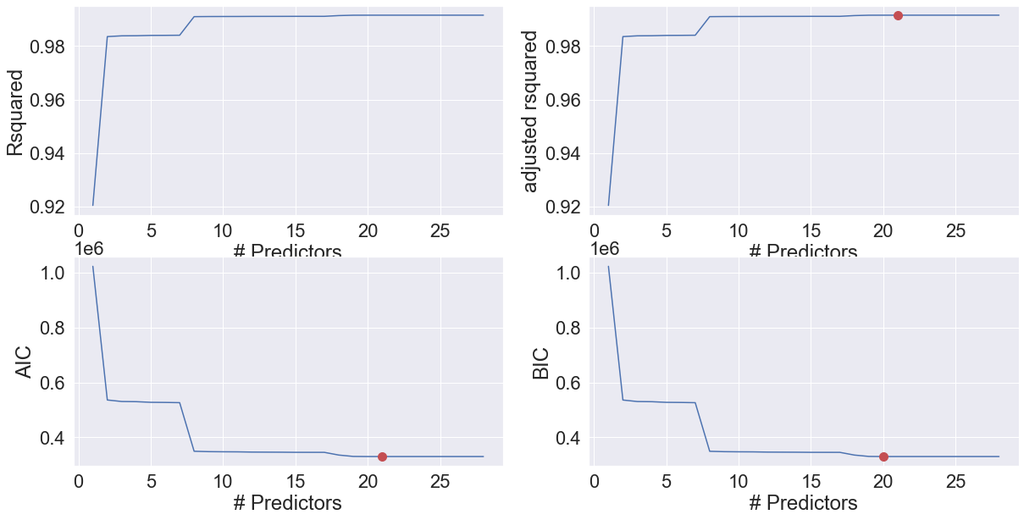

```python
def best_sub_plots():
    plt.figure(figsize=(20,10))
    plt.rcParams.update({'font.size': 18, 'lines.markersize': 10})

    # Set up a 2x2 grid so we can look at 4 plots at once
    plt.subplot(2, 2, 1)

    # We will now plot a red dot to indicate the model with the largest adjusted R^2 statistic.
    # The argmax() function can be used to identify the location of the maximum point of a vector
    plt.plot(models_best["Rsquared"])
    plt.xlabel('# Predictors')
    plt.ylabel('Rsquared')

    # We will now plot a red dot to indicate the model with the largest adjusted R^2 statistic.
    # The argmax() function can be used to identify the location of the maximum point of a vector

    rsquared_adj = models_best.apply(lambda row: row[1].rsquared_adj, axis=1)

    plt.subplot(2, 2, 2)
    plt.plot(rsquared_adj)
    plt.plot(1+rsquared_adj.argmax(), rsquared_adj.max(), "or")
    plt.xlabel('# Predictors')
    plt.ylabel('adjusted rsquared')

    # We'll do the same for AIC and BIC, this time looking for the models with the SMALLEST statistic
    aic = models_best.apply(lambda row: row[1].aic, axis=1)

    plt.subplot(2, 2, 3)
    plt.plot(aic)
    plt.plot(1+aic.argmin(), aic.min(), "or")
    plt.xlabel('# Predictors')
    plt.ylabel('AIC')

    bic = models_best.apply(lambda row: row[1].bic, axis=1)

    plt.subplot(2, 2, 4)
    plt.plot(bic)
    plt.plot(1+bic.argmin(), bic.min(), "or")
    plt.xlabel('# Predictors')
    plt.ylabel('BIC')
best_sub_plots()
```

```python
best_fwd_reg_model = models_best['model'][20]
best_fwd_reg_model.summary()
```

OLS Regression Results

| Dep. Variable: | T_degC | R-squared: | 0.992 |
| --- | --- | --- | --- |
| Model: | OLS | Adj. R-squared: | 0.992 |
| Method: | Least Squares | F-statistic: | 1.812e+06 |
| Date: | Tue, 14 Mar 2023 | Prob (F-statistic): | 0.00 |
| Time: | 23:06:23 | Log-Likelihood: | -1.6504e+05 |
| No. Observations: | 308807 | AIC: | 3.301e+05 |
| Df Residuals: | 308786 | BIC: | 3.303e+05 |
| Df Model: | 20 |  |  |
| Covariance Type: | nonrobust |  |  |

|  | coef | std err | t | P>\|t\| | [0.025 | 0.975] |
| --- | --- | --- | --- | --- | --- | --- |
| Intercept | 199.9186 | 2.838 | 70.443 | 0.000 | 194.356 | 205.481 |
| STheta | -15.8726 | 0.095 | -167.343 | 0.000 | -16.059 | -15.687 |
| Salnty | -1.8519 | 0.082 | -22.598 | 0.000 | -2.013 | -1.691 |
| Salnty_STheta | 0.3216 | 0.003 | 118.891 | 0.000 | 0.316 | 0.327 |
| STheta_RecInd | 0.0441 | 0.001 | 40.905 | 0.000 | 0.042 | 0.046 |
| Salnty_RecInd | 0.0663 | 0.002 | 36.126 | 0.000 | 0.063 | 0.070 |
| O2ml_L_RecInd | 0.0233 | 0.001 | 37.190 | 0.000 | 0.022 | 0.024 |
| O2ml_L_STheta | 0.3809 | 0.001 | 512.726 | 0.000 | 0.379 | 0.382 |
| Salnty_O2ml_L | -0.2410 | 0.001 | -164.260 | 0.000 | -0.244 | -0.238 |
| RecInd | -3.3915 | 0.075 | -45.228 | 0.000 | -3.538 | -3.245 |
| O2ml_L_S_prec | -0.2829 | 0.003 | -107.441 | 0.000 | -0.288 | -0.278 |
| STheta_T_prec | -0.3005 | 0.013 | -23.122 | 0.000 | -0.326 | -0.275 |
| T_prec | 24.0382 | 0.823 | 29.225 | 0.000 | 22.426 | 25.650 |
| O2ml_L | -0.8207 | 0.052 | -15.843 | 0.000 | -0.922 | -0.719 |
| Salnty_T_prec | -0.4770 | 0.022 | -21.229 | 0.000 | -0.521 | -0.433 |
| O2ml_L_T_prec | -0.1562 | 0.008 | -18.704 | 0.000 | -0.173 | -0.140 |
| RecInd_T_prec | 0.0394 | 0.005 | 7.907 | 0.000 | 0.030 | 0.049 |
| STheta_S_prec | -0.5176 | 0.004 | -116.978 | 0.000 | -0.526 | -0.509 |
| S_prec | 32.7107 | 0.311 | 105.117 | 0.000 | 32.101 | 33.321 |
| Salnty_S_prec | -0.5353 | 0.008 | -71.284 | 0.000 | -0.550 | -0.521 |
| RecInd_S_prec | -0.0583 | 0.003 | -20.960 | 0.000 | -0.064 | -0.053 |

| Omnibus: | 193908.167 | Durbin-Watson: | 0.337 |
| --- | --- | --- | --- |
| Prob(Omnibus): | 0.000 | Jarque-Bera (JB): | 3635928.786 |
| Skew: | -2.716 | Prob(JB): | 0.00 |
| Kurtosis: | 18.909 | Cond. No. | 3.60e+06 |

Notes:  
[1] Standard Errors assume that the covariance matrix of the errors is correctly specified.  
[2] The condition number is large, 3.6e+06. This might indicate that there are  
strong multicollinearity or other numerical problems.

```python
pred_temp_fwd = best_fwd_reg_model.predict(testing)
RMSE_fwd = np.sqrt(((pred_temp_fwd - testing.T_degC)**2).mean())
print(RMSE_fwd)
```

```
0.41796090705679884
```

### 3.1 Model (Without STheta, With Depthm)

Anirudh Poranki

```python
X_n = training[['Salnty','O2ml_L', 'RecInd','T_prec','S_prec','P_qual','Depthm']]
X_n_backup = training[['Salnty','O2ml_L', 'RecInd','T_prec','S_prec','P_qual','Depthm']]
```

```python
for combo in itertools.combinations(X_n.columns, 2):
    training['_'.join(combo)] = training[combo[0]]*training[combo[1]]
    testing['_'.join(combo)] = testing[combo[0]]*testing[combo[1]]
    X_n.loc[:,'_'.join(combo)] = training.loc[:,'_'.join(combo)]
```

```python
def forward(predictors):

    # Pull out predictors we still need to process
    remaining_predictors = [p for p in X_n.columns if p not in predictors]

    tic = time.time()

    results = []

    for p in remaining_predictors:
        results.append(processSubset(predictors+[p]))

    # Wrap everything up in a nice dataframe
    models = pd.DataFrame(results)

    # Choose the model with the highest RSS
    best_model = models.loc[models['Rsquared'].argmax()]

    toc = time.time()
    print("Processed ", models.shape[0], "models on", len(predictors)+1, "predictors in", (toc-tic), "seconds.")

    # Return the best model, along with some other useful information about the model
    return best_model
```

```python
def forward_selection():
    models_best = pd.DataFrame(columns=["Rsquared", "model"])

    tic = time.time()
    predictors = []

    for i in range(1,len(X_n.columns)+1):
        models_best.loc[i] = forward(predictors)
        predictors = list(models_best.loc[i]["model"].params.index[1:])

    toc = time.time()
    print("Total elapsed time:", (toc-tic), "seconds.")
    return models_best
```

```python
models_best = forward_selection()
```

```
Processed  28 models on 1 predictors in 1.7344908714294434 seconds.
Processed  27 models on 2 predictors in 1.6491718292236328 seconds.
Processed  26 models on 3 predictors in 2.111637830734253 seconds.
Processed  25 models on 4 predictors in 2.4104421138763428 seconds.
Processed  24 models on 5 predictors in 2.9260499477386475 seconds.
Processed  23 models on 6 predictors in 3.1356611251831055 seconds.
Processed  22 models on 7 predictors in 3.7078299522399902 seconds.
Processed  21 models on 8 predictors in 3.8232948780059814 seconds.
Processed  20 models on 9 predictors in 4.280067682266235 seconds.
Processed  19 models on 10 predictors in 4.497695207595825 seconds.
Processed  18 models on 11 predictors in 4.93912672996521 seconds.
Processed  17 models on 12 predictors in 5.046025991439819 seconds.
Processed  16 models on 13 predictors in 4.851282835006714 seconds.
Processed  15 models on 14 predictors in 5.651544094085693 seconds.
Processed  14 models on 15 predictors in 5.384093761444092 seconds.
Processed  13 models on 16 predictors in 5.150438070297241 seconds.
Processed  12 models on 17 predictors in 5.255874872207642 seconds.
Processed  11 models on 18 predictors in 5.3812479972839355 seconds.
Processed  10 models on 19 predictors in 4.87945818901062 seconds.
Processed  9 models on 20 predictors in 4.874335050582886 seconds.
Processed  8 models on 21 predictors in 4.6878821849823 seconds.
Processed  7 models on 22 predictors in 4.264879941940308 seconds.
Processed  6 models on 23 predictors in 4.173537015914917 seconds.
Processed  5 models on 24 predictors in 3.436795949935913 seconds.
Processed  4 models on 25 predictors in 2.5936238765716553 seconds.
Processed  3 models on 26 predictors in 2.0995941162109375 seconds.
Processed  2 models on 27 predictors in 1.4217979907989502 seconds.
Processed  1 models on 28 predictors in 0.8292100429534912 seconds.
Total elapsed time: 108.12762808799744 seconds.
```

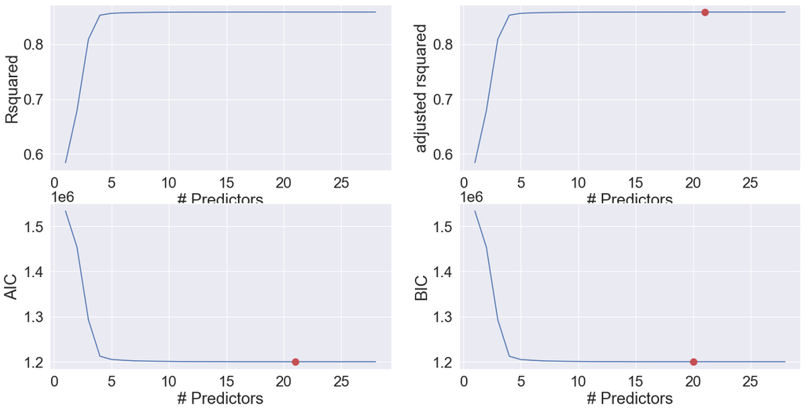

```python
best_sub_plots()
```

```python
best_fwd_reg_model_no = models_best['model'][20]
best_fwd_reg_model_no.summary()
```

OLS Regression Results

| Dep. Variable: | T_degC | R-squared: | 0.859 |
| --- | --- | --- | --- |
| Model: | OLS | Adj. R-squared: | 0.859 |
| Method: | Least Squares | F-statistic: | 9.382e+04 |
| Date: | Tue, 14 Mar 2023 | Prob (F-statistic): | 0.00 |
| Time: | 23:08:35 | Log-Likelihood: | -5.9997e+05 |
| No. Observations: | 308807 | AIC: | 1.200e+06 |
| Df Residuals: | 308786 | BIC: | 1.200e+06 |
| Df Model: | 20 |  |  |
| Covariance Type: | nonrobust |  |  |

|  | coef | std err | t | P>\|t\| | [0.025 | 0.975] |
| --- | --- | --- | --- | --- | --- | --- |
| Intercept | -124.5997 | 7.132 | -17.471 | 0.000 | -138.578 | -110.621 |
| Salnty_O2ml_L | 0.0112 | 0.006 | 1.985 | 0.047 | 0.000 | 0.022 |
| Salnty | 4.0849 | 0.207 | 19.712 | 0.000 | 3.679 | 4.491 |
| P_qual_Depthm | -0.0650 | 0.000 | -253.715 | 0.000 | -0.066 | -0.065 |
| Salnty_Depthm | 0.0167 | 6.7e-05 | 249.163 | 0.000 | 0.017 | 0.017 |
| O2ml_L_Depthm | -0.0006 | 9.08e-06 | -71.323 | 0.000 | -0.001 | -0.001 |
| O2ml_L_S_prec | -0.1213 | 0.007 | -18.133 | 0.000 | -0.134 | -0.108 |
| O2ml_L_RecInd | 0.0081 | 0.002 | 5.206 | 0.000 | 0.005 | 0.011 |
| S_prec_Depthm | 0.0010 | 2.99e-05 | 34.052 | 0.000 | 0.001 | 0.001 |
| RecInd_Depthm | -0.0001 | 6.06e-06 | -20.287 | 0.000 | -0.000 | -0.000 |
| Salnty_S_prec | -0.2540 | 0.030 | -8.401 | 0.000 | -0.313 | -0.195 |
| S_prec | 7.3303 | 1.093 | 6.706 | 0.000 | 5.188 | 9.473 |
| O2ml_L_P_qual | 0.1404 | 0.022 | 6.273 | 0.000 | 0.097 | 0.184 |
| T_prec_Depthm | 0.0004 | 6.05e-05 | 7.392 | 0.000 | 0.000 | 0.001 |
| T_prec | -20.4520 | 3.422 | -5.976 | 0.000 | -27.160 | -13.744 |
| RecInd_T_prec | 0.0647 | 0.039 | 1.673 | 0.094 | -0.011 | 0.140 |
| Salnty_RecInd | -0.0563 | 0.007 | -7.502 | 0.000 | -0.071 | -0.042 |
| RecInd_P_qual | 0.2049 | 0.030 | 6.853 | 0.000 | 0.146 | 0.264 |
| T_prec_S_prec | 0.5289 | 0.164 | 3.222 | 0.001 | 0.207 | 0.851 |
| O2ml_L_T_prec | 0.1593 | 0.026 | 6.112 | 0.000 | 0.108 | 0.210 |
| Salnty_T_prec | 0.5219 | 0.099 | 5.248 | 0.000 | 0.327 | 0.717 |

| Omnibus: | 62200.368 | Durbin-Watson: | 0.344 |
| --- | --- | --- | --- |
| Prob(Omnibus): | 0.000 | Jarque-Bera (JB): | 347284.009 |
| Skew: | 0.859 | Prob(JB): | 0.00 |
| Kurtosis: | 7.903 | Cond. No. | 4.36e+07 |

Notes:  
[1] Standard Errors assume that the covariance matrix of the errors is correctly specified.  
[2] The condition number is large, 4.36e+07. This might indicate that there are  
strong multicollinearity or other numerical problems.

```python
pred_t = best_fwd_reg_model_no.predict(testing)
RMSE_no = np.sqrt(((pred_t - testing.T_degC)**2).mean())
print(RMSE_no)
```

```
1.7013238543426865
```

### 3.2 Model (With Neither)

Anirudh Poranki

```python
X_n_2 = training[['Salnty','O2ml_L', 'RecInd','T_prec','S_prec','P_qual']]
X_n_backup_2 = training[['Salnty','O2ml_L', 'RecInd','T_prec','S_prec','P_qual']]
```

```python
for combo in itertools.combinations(X_n_2.columns, 2):
    training['_'.join(combo)] = training[combo[0]]*training[combo[1]]
    testing['_'.join(combo)] = testing[combo[0]]*testing[combo[1]]
    X_n_2.loc[:,'_'.join(combo)] = training.loc[:,'_'.join(combo)]
```

```python
def forward(predictors):

    # Pull out predictors we still need to process
    remaining_predictors = [p for p in X_n_2.columns if p not in predictors]

    tic = time.time()

    results = []

    for p in remaining_predictors:
        results.append(processSubset(predictors+[p]))

    # Wrap everything up in a nice dataframe
    models = pd.DataFrame(results)

    # Choose the model with the highest RSS
    best_model = models.loc[models['Rsquared'].argmax()]

    toc = time.time()
    print("Processed ", models.shape[0], "models on", len(predictors)+1, "predictors in", (toc-tic), "seconds.")

    # Return the best model, along with some other useful information about the model
    return best_model
```

```python
def forward_selection():
    models_best = pd.DataFrame(columns=["Rsquared", "model"])

    tic = time.time()
    predictors = []

    for i in range(1,len(X_n_2.columns)+1):
        models_best.loc[i] = forward(predictors)
        predictors = list(models_best.loc[i]["model"].params.index[1:])

    toc = time.time()
    print("Total elapsed time:", (toc-tic), "seconds.")
    return models_best
```

```python
models_best = forward_selection()
```

```
Processed  21 models on 1 predictors in 1.1434292793273926 seconds.
Processed  20 models on 2 predictors in 1.3671741485595703 seconds.
Processed  19 models on 3 predictors in 1.6602797508239746 seconds.
Processed  18 models on 4 predictors in 1.8772799968719482 seconds.
Processed  17 models on 5 predictors in 2.1202609539031982 seconds.
Processed  16 models on 6 predictors in 2.2359249591827393 seconds.
Processed  15 models on 7 predictors in 2.33699893951416 seconds.
Processed  14 models on 8 predictors in 2.514213800430298 seconds.
Processed  13 models on 9 predictors in 2.68229603767395 seconds.
Processed  12 models on 10 predictors in 2.717410087585449 seconds.
Processed  11 models on 11 predictors in 2.7491040229797363 seconds.
Processed  10 models on 12 predictors in 2.804382085800171 seconds.
Processed  9 models on 13 predictors in 2.813810110092163 seconds.
Processed  8 models on 14 predictors in 2.7271859645843506 seconds.
Processed  7 models on 15 predictors in 2.5837371349334717 seconds.
Processed  6 models on 16 predictors in 2.3249189853668213 seconds.
Processed  5 models on 17 predictors in 2.0393178462982178 seconds.
Processed  4 models on 18 predictors in 1.761357069015503 seconds.
Processed  3 models on 19 predictors in 1.4183871746063232 seconds.
Processed  2 models on 20 predictors in 1.0010502338409424 seconds.
Processed  1 models on 21 predictors in 0.5186631679534912 seconds.
Total elapsed time: 44.683207750320435 seconds.
```

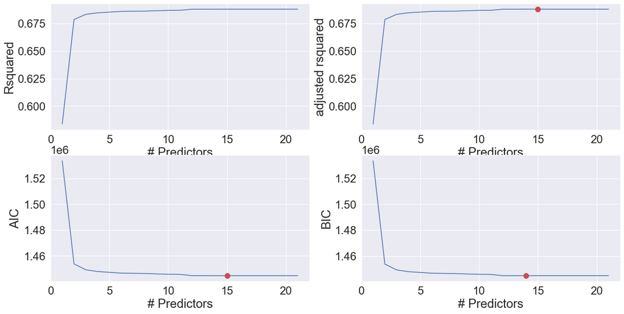

```python
best_sub_plots()
```

```python
best_fwd_reg_model_no_2 = models_best['model'][15]
best_fwd_reg_model_no_2.summary()
```

OLS Regression Results

| Dep. Variable: | T_degC | R-squared: | 0.688 |
| --- | --- | --- | --- |
| Model: | OLS | Adj. R-squared: | 0.688 |
| Method: | Least Squares | F-statistic: | 4.539e+04 |
| Date: | Tue, 14 Mar 2023 | Prob (F-statistic): | 0.00 |
| Time: | 23:09:54 | Log-Likelihood: | -7.2228e+05 |
| No. Observations: | 308807 | AIC: | 1.445e+06 |
| Df Residuals: | 308791 | BIC: | 1.445e+06 |
| Df Model: | 15 |  |  |
| Covariance Type: | nonrobust |  |  |

|  | coef | std err | t | P>\|t\| | [0.025 | 0.975] |
| --- | --- | --- | --- | --- | --- | --- |
| Intercept | -402.7074 | 9.849 | -40.888 | 0.000 | -422.011 | -383.403 |
| Salnty_O2ml_L | -0.1722 | 0.006 | -27.422 | 0.000 | -0.185 | -0.160 |
| Salnty | 12.0936 | 0.285 | 42.431 | 0.000 | 11.535 | 12.652 |
| T_prec_S_prec | 0.7070 | 0.244 | 2.902 | 0.004 | 0.229 | 1.185 |
| O2ml_L | 9.2413 | 0.231 | 40.036 | 0.000 | 8.789 | 9.694 |
| O2ml_L_RecInd | 0.0498 | 0.002 | 21.517 | 0.000 | 0.045 | 0.054 |
| O2ml_L_S_prec | -0.3656 | 0.010 | -38.338 | 0.000 | -0.384 | -0.347 |
| RecInd_T_prec | 0.1381 | 0.057 | 2.402 | 0.016 | 0.025 | 0.251 |
| Salnty_T_prec | -1.7381 | 0.137 | -12.724 | 0.000 | -2.006 | -1.470 |
| RecInd_S_prec | -0.2290 | 0.016 | -13.924 | 0.000 | -0.261 | -0.197 |
| T_prec | 55.1012 | 4.720 | 11.673 | 0.000 | 45.849 | 64.353 |
| Salnty_S_prec | -1.2201 | 0.044 | -27.674 | 0.000 | -1.307 | -1.134 |
| S_prec | 41.1092 | 1.598 | 25.718 | 0.000 | 37.976 | 44.242 |
| Salnty_RecInd | 0.0679 | 0.011 | 6.198 | 0.000 | 0.046 | 0.089 |
| RecInd | -1.9951 | 0.399 | -5.002 | 0.000 | -2.777 | -1.213 |
| O2ml_L_T_prec | -0.0812 | 0.039 | -2.104 | 0.035 | -0.157 | -0.006 |

| Omnibus: | 30604.481 | Durbin-Watson: | 0.311 |
| --- | --- | --- | --- |
| Prob(Omnibus): | 0.000 | Jarque-Bera (JB): | 196947.959 |
| Skew: | -0.251 | Prob(JB): | 0.00 |
| Kurtosis: | 6.880 | Cond. No. | 5.70e+05 |

Notes:  
[1] Standard Errors assume that the covariance matrix of the errors is correctly specified.  
[2] The condition number is large, 5.7e+05. This might indicate that there are  
strong multicollinearity or other numerical problems.

```python
pred_t_2 = best_fwd_reg_model_no_2.predict(testing)
RMSE_no_2 = np.sqrt(((pred_t_2 - testing.T_degC)**2).mean())
print(RMSE_no_2)
```

```
2.523800644350754
```

### 3.3 Ridge Regression (on previous Model)

Anirudh Poranki

```python
split = (np.random.rand(len(data_cleaned)) <= 0.75)
training = data_cleaned[split]
testing = data_cleaned[~split]

print(f"No. of training examples: {training.shape[0]}")
print(f"No. of testing examples: {testing.shape[0]}")
```

```
No. of training examples: 289886
No. of testing examples: 96486
```

```python
y = training['T_degC']
```

```python
X_n_backup = training[['Salnty','O2ml_L', 'RecInd','T_prec','S_prec','P_qual']]
```

```python
for combo in itertools.combinations(X_n_backup.columns, 2):
    training['_'.join(combo)] = training[combo[0]]*training[combo[1]]
    testing['_'.join(combo)] = testing[combo[0]]*testing[combo[1]]
    X_n_backup.loc[:,'_'.join(combo)] = training.loc[:,'_'.join(combo)]
```

```python
from sklearn.preprocessing import StandardScaler
from sklearn.linear_model import Ridge, RidgeCV, Lasso, LassoCV

#Defining a scaler object
scaler = StandardScaler()

#The scaler object will contain the mean and variance of each column (predictor) of X.
#These values will be useful to scale test data based on the same mean and variance as obtained on train data
scaler.fit(X_n_backup)

#Using the scaler object (or the values of mean and variance stored in it) to standardize X (or train data)
X_nstd = scaler.transform(X_n_backup)

#Alphas
alphas = 10**np.linspace(2,0.5,200)*0.5
coefs = []
for a in alphas:
    ridge = Ridge(alpha = a)
    ridge.fit(X_nstd, y)
    coefs.append(ridge.coef_)

#Optimal Lambda
ridgecv = RidgeCV(alphas = alphas,store_cv_values=True)
ridgecv.fit(X_nstd, y)

#Optimal value of the tuning parameter - lambda
print("The optimal value is " + str(ridgecv.alpha_))
```

```
The optimal value is 16.181555070198364
```

```python
#Standarized test data
#Test dataset
X_test = testing[X_n_backup.columns]
#Standardizing test data
X_test_std = scaler.transform(X_test)
```

```python
ridge = Ridge(alpha = ridgecv.alpha_)
ridge.fit(X_nstd, y)
#Test 1 and Test 2
pred_r=ridge.predict(X_test_std)
```

```python
ridge_coef = pd.DataFrame({'feature': X_n_backup.columns, 'coefficient': ridge.coef_})
ridge_coef
```

|  | feature | coefficient |
| --- | --- | --- |
| 0 | Salnty | 1.924043 |
| 1 | O2ml_L | 5.563063 |
| 2 | RecInd | 1.200685 |
| 3 | T_prec | 1.205012 |
| 4 | S_prec | 3.272156 |
| 5 | P_qual | -0.126338 |
| 6 | Salnty_O2ml_L | -5.501401 |
| 7 | Salnty_RecInd | -1.754880 |
| 8 | Salnty_T_prec | -2.996832 |
| 9 | Salnty_S_prec | -7.127500 |
| 10 | Salnty_P_qual | 1.916109 |
| 11 | O2ml_L_RecInd | 0.413681 |
| 12 | O2ml_L_T_prec | 0.543430 |
| 13 | O2ml_L_S_prec | -1.312009 |
| 14 | O2ml_L_P_qual | 5.562856 |
| 15 | RecInd_T_prec | 0.680780 |
| 16 | RecInd_S_prec | -1.658984 |
| 17 | RecInd_P_qual | 1.200565 |
| 18 | T_prec_S_prec | 0.884395 |
| 19 | T_prec_P_qual | 1.203251 |
| 20 | S_prec_P_qual | 3.271652 |

```python
RMSE_1 = np.sqrt(((pred_r - testing.T_degC)**2).mean())
RMSE_1
```

```
2.5168280668727046
```

```python
y_test = testing['T_degC']
```

```python
from sklearn.metrics import r2_score
r2 = ridge.score(X_test_std, y_test)
r2
```

```
0.6871547391710832
```

### 3.4 Lasso

```python
lasso = Lasso(max_iter = 10000)
coefs = []

for a in alphas:
    lasso.set_params(alpha=a)
    lasso.fit(X_nstd, y)
    coefs.append(lasso.coef_)
```

```python
lassocv = LassoCV(alphas = alphas, cv = 10, max_iter = 100000)
lassocv.fit(X_nstd, y)

#Optimal value of the tuning parameter - lamda
print("The optimal value is " + str(lassocv.alpha_))
```

```
The optimal value is 1.5811388300841898
```

```python
lasso = Lasso(alpha = lassocv.alpha_)
lasso.fit(X_nstd, y)
pred_lasso = lasso.predict(X_test_std)
#RMSE
RMSE_lasso = np.sqrt(((pred_lasso - testing.T_degC)**2).mean())
RMSE_lasso
```

```
3.310499963243965
```

```python
lasso_coef = pd.DataFrame({'feature': X_n_backup.columns, 'coefficient': lasso.coef_})
lasso_coef
```

|  | feature | coefficient |
| --- | --- | --- |
| 0 | Salnty | -0.000000 |
| 1 | O2ml_L | 0.000000 |
| 2 | RecInd | -0.000000 |
| 3 | T_prec | -0.000000 |
| 4 | S_prec | -0.000000 |
| 5 | P_qual | 0.000000 |
| 6 | Salnty_O2ml_L | 1.853134 |
| 7 | Salnty_RecInd | -0.000000 |
| 8 | Salnty_T_prec | -0.000000 |
| 9 | Salnty_S_prec | -0.000000 |
| 10 | Salnty_P_qual | -0.000000 |
| 11 | O2ml_L_RecInd | 0.000000 |
| 12 | O2ml_L_T_prec | 0.000000 |
| 13 | O2ml_L_S_prec | 0.000000 |
| 14 | O2ml_L_P_qual | 0.000000 |
| 15 | RecInd_T_prec | -0.000000 |
| 16 | RecInd_S_prec | -0.000000 |
| 17 | RecInd_P_qual | -0.000000 |
| 18 | T_prec_S_prec | -0.000000 |
| 19 | T_prec_P_qual | -0.000000 |
| 20 | S_prec_P_qual | -0.000000 |

```python
r2 = lasso.score(X_test_std, y_test)
r2
```

```
0.45873535733635007
```

### 3.5 Code fitting the final model

```python
split = (np.random.rand(len(data_cleaned)) <= 0.75)
training = data_cleaned[split]
testing = data_cleaned[~split]

print(f"No. of training examples: {training.shape[0]}")
print(f"No. of testing examples: {testing.shape[0]}")
```

```
No. of training examples: 289796
No. of testing examples: 96576
```

## 4 Ridge (on 1st Model)

```python
y = training['T_degC']
X_n_backup = training[['STheta','Salnty','O2ml_L', 'RecInd','T_prec','S_prec','P_qual']]
for combo in itertools.combinations(X_n_backup.columns, 2):
    training['_'.join(combo)] = training[combo[0]]*training[combo[1]]
    testing['_'.join(combo)] = testing[combo[0]]*testing[combo[1]]
    X_n_backup.loc[:,'_'.join(combo)] = training.loc[:,'_'.join(combo)]
```

```python
from sklearn.preprocessing import StandardScaler
from sklearn.linear_model import Ridge, RidgeCV, Lasso, LassoCV

#Defining a scaler object
scaler = StandardScaler()

#The scaler object will contain the mean and variance of each column (predictor) of X.
#These values will be useful to scale test data based on the same mean and variance as obtained on train data
scaler.fit(X_n_backup)

#Using the scaler object (or the values of mean and variance stored in it) to standardize X (or train data)
X_nstd = scaler.transform(X_n_backup)

#Alphas
alphas = 10**np.linspace(2,0.5,200)*0.5
coefs = []
for a in alphas:
    ridge = Ridge(alpha = a)
    ridge.fit(X_nstd, y)
    coefs.append(ridge.coef_)

#Optimal Lambda
ridgecv = RidgeCV(alphas = alphas,store_cv_values=True)
ridgecv.fit(X_nstd, y)

#Optimal value of the tuning parameter - lambda
print("The optimal value is " + str(ridgecv.alpha_))
```

```
The optimal value is 1.5811388300841898
```

```python
#Standarized test data
#Test dataset
X_test = testing[X_n_backup.columns]
#Standardizing test data
X_test_std = scaler.transform(X_test)
```

```python
ridge = Ridge(alpha = ridgecv.alpha_)
ridge.fit(X_nstd, y)
#Test 1 and Test 2
pred_r=ridge.predict(X_test_std)
```

```python
ridge_coef = pd.DataFrame({'feature': X_n_backup.columns, 'coefficient': ridge.coef_})
ridge_coef
```

|  | feature | coefficient |
| --- | --- | --- |
| 0 | STheta | -7.320963 |
| 1 | Salnty | -0.249372 |
| 2 | O2ml_L | -0.838478 |
| 3 | RecInd | -1.978687 |
| 4 | T_prec | 1.130826 |
| 5 | S_prec | 5.946620 |
| 6 | P_qual | 0.000000 |
| 7 | STheta_Salnty | 11.840917 |
| 8 | STheta_O2ml_L | 18.533754 |
| 9 | STheta_RecInd | 1.709203 |
| 10 | STheta_T_prec | -1.004657 |
| 11 | STheta_S_prec | -5.860874 |
| 12 | STheta_P_qual | -7.320963 |
| 13 | Salnty_O2ml_L | -16.014405 |
| 14 | Salnty_RecInd | 2.430799 |
| 15 | Salnty_T_prec | -1.545750 |
| 16 | Salnty_S_prec | -6.105374 |
| 17 | Salnty_P_qual | -0.249372 |
| 18 | O2ml_L_RecInd | 0.165134 |
| 19 | O2ml_L_T_prec | -0.655862 |
| 20 | O2ml_L_S_prec | -1.277676 |
| 21 | O2ml_L_P_qual | -0.838478 |
| 22 | RecInd_T_prec | 0.041092 |
| 23 | RecInd_S_prec | -0.356336 |
| 24 | RecInd_P_qual | -1.978687 |
| 25 | T_prec_S_prec | 0.138930 |
| 26 | T_prec_P_qual | 1.130826 |
| 27 | S_prec_P_qual | 5.946620 |

```python
RMSE_1 = np.sqrt(((pred_r - testing.T_degC)**2).mean())
print(RMSE_1)
y_test = testing['T_degC']
from sklearn.metrics import r2_score
r2 = ridge.score(X_test_std, y_test)
print(r2)
```

```
0.44032027869090085
0.9904449317847488
```